# PandasSummary

## Index

1. Series[Link]
- Series.index
- Series.values
- Series.index minimum value[Link]
- Series.index maximum value[Link]
2. Values & Index , Search and Selection
- Values selection by Index[Link]
- Values selection by Values Condition[Link]
- Searching Index values in Objects[Link]
- Searching Values in Objects[Link]
3. Data Broadcasting[Link]
4. From Dict to Pandas
- Create Series from Dictionary[Link]
- Create Dataframe from Dictionary[Link]
5. Python function
- Map function
- Format function --> float to number[Link]
- def function[Link]
- Apply function[Link] [Link2]
- Lambda function[Link]
- Map function[Link]
- Applymap function[Link]
- Numpy.nan[Link]
- np.where[Link]
- np.linspace[Link]
- For Loop[Link]
6. Dataframe Functions
- pd.isnull[Link1] [Link2]
- pd.notnull[Link1] [Link2]
- Frame.sort_values[Link]
- np.sort[Link]
- Frame.Ix[Link]
- Frame.Reindex[Link]
- Frame.Drop[Link1] [Link2] [Link3]
- pd.Panel[Link]
- pd.Swapaxes[Link]
- pd.pct_change[Link1] [Link2] [shift(1)]
- pd.Covariance[Link]
- pd.Correlation[Link] [Link2]
- pd.Correlationwith[Link]
- frame.rolling[Link] [Link]
- frame.append[Link]
- pd.to_frame
- pd.join[Link] [Link2]
- pd.merge[Link]
- merge function inputs[Link]
- merge how = outer[Link]
- merge how = on[Link]
- merge how = left_on[Link]
- merge how = right_on[Link]
- merge how = left_index[Link]
- merge how = right_index[Link]
- pd.concat[Link] [Link2]
- pd.combine_first
- Functions in Pandas
- Frame.fillna[Link] [Link2] [Link3]
- frame.dropna[Link] [Link2]
- frame.median[Link]
- frame.mad[Link]
- frame.var[Link]
- frame.std[Link]
- frame.skew[Link]
- frame.kurt[Link]
- frame.unique[Link]
- frame.value_counts[Link] [Link2]
- frame.isin[Link]
- Frame.unstack[Link]
- Frame.stack[Link]
- Frame.swaplevel[Link]
- Frame.groupby[Link]
- GroupedFrame.size[Link]
- GroupedFrame.sum[Link]
- GroupedFrame.describe[Link]
- GroupedFrame.get_group[Link]
- GroupedFrame.Aggregate[Link]
- GroupedFrame.mean[Link]
- GroupedFrame.filter[Link]
7. Getting information from Pandas Dataframe
- Object name[Link]
- Object Index.name[Link]
- Frame.Index[Link]
- Frame.Index.name[Link]
- Frame.Columns[Link]
- Frame.columns.name[Link]
- Frame.Values[Link]
- Calling Frame Columns[Link]
- Add Column to Frame[Link]
- Add Column to Frame using conditional clause[Link]
- Del Column to Frame[Link1] [Link2]
- Change Column position in frame[Link]
- Drop Values from Series by Index
- Del Values from Frame by Column
- Updating values in the Dataframe
- Changing Column values[Link]
- Changing Row values[Link]
- Changing Cell values[Link]
8. Float numbers
9. Vectorized Operations[Link]
10. Creating Date_Range
- Date_Range Function[Link2] [Link2]
- Date_Range parameters[Parameters] [Frequency]
11. Converting np.datetime64 to timestamp[Link]
12. Basic plotting
- .plot[Link] [Link2] [Link3]
- .subplot[Link]
- .hist[Link]
- .boxplot[Link]
- Custom plots
13. Web.Datareader[Link]
14. OLS Regression[Link]
15. Pandas Indexing
- Indexing Options --> Useful Functions (Table)[Link]
- Hierarchical Indexing[Link]
16. Importing multiple sheets from an Excel file to a Dictionary[Link]
17. Apply formulas to every row[Link]
18. Convert Dataframe to HTML[Link]
19. Pivot Tables[Link]
20. IPython.display[Link]

```python
import pandas as pd
import numpy as np
#from pandas_datareader import data as web
import datetime as dt
%matplotlib inline
import seaborn as sns; sns.set()
import math
import zmq
import statsmodels.api as sm
import matplotlib.pyplot as plt
```

## Basic Pandas

In a sense, **`pandas` is built "on top" of `NumPy`**. For example, `NumPy` universal functions will generally work on `pandas` objects as well. We therefore import both to begin with.

On a rather fundamental level, the `DataFrame` class is designed to manage **indexed and labeled data**.

### Introduction to Data Analysis with Pandas

```python
obj = Series([4,5,-7,3], index =['A','B','C','D'])
obj
```

[output not shown]

```python
print 'Index details'
print obj.index
print 'Values details'
print obj.values
```

```
Index details
Index([u'A', u'B', u'C', u'D'], dtype='object')
Values details
[ 4  5 -7  3]
```

```python
# Selecting specific values based on its index
obj['A']
```

```
4
```

```python
# Select multiple values based on their index
obj[['A','C']]
```

```
A    4
C   -7
dtype: int64
```

```python
# Filtering data based on a given criteria
obj[obj>0]
```

```
A    4
B    5
D    3
dtype: int64
```

```python
obj[(obj > 4) | (obj < 0)]
```

[output not shown]

```python
obj.idxmax()
```

```
'B'
```

```python
obj.idxmin()
```

```
'C'
```

```python
obj.argmin()
```

```
'C'
```

```python
# Checking boolean
'B' in obj
```

```
True
```

```python
4 in obj.values
```

```
True
```

```python
sdata = {'Ohio': 35000, 'Texas': 71000, 'Oregon': 16000, 'Utah': 5000}
obj3 = Series(sdata)
print obj3
```

```
Ohio      35000
Oregon    16000
Texas     71000
Utah       5000
dtype: int64
```

```python
states = ['California', 'Ohio','Oregon', 'Texas']
```

```python
obj4 = Series(sdata, index = states)

#it takes the values of sdata but using as index the states data
# if there is a match it populates the value field
```

```python
obj4
```

```
California        NaN
Ohio          35000.0
Oregon        16000.0
Texas         71000.0
dtype: float64
```

```python
# Pandas functions
print pd.isnull(obj4)
print pd.notnull(obj4)
```

```
California     True
Ohio          False
Oregon        False
Texas         False
dtype: bool
California    False
Ohio           True
Oregon         True
Texas          True
dtype: bool
```

```python
# Data manipulation
obj * 2
```

```
A     8
B    10
C   -14
D     6
dtype: int64
```

```python
np.exp(obj)
```

```
A     54.598150
B    148.413159
C      0.000912
D     20.085537
dtype: float64
```

```python
# Combining Series
obj3 + obj4
```

```
California         NaN
Ohio           70000.0
Oregon         32000.0
Texas         142000.0
Utah               NaN
dtype: float64
```

```python
obj4.name = 'Population'
```

```python
obj4.index.name = 'states'
```

```python
obj4
```

```
states
California        NaN
Ohio          35000.0
Oregon        16000.0
Texas         71000.0
Name: Population, dtype: float64
```

### Changing numbers format in Pandas Dataframe

The following example already shows some major features of the `DataFrame` class when it comes to storing data:

- **data**: data itself can be provided in different shapes and types
- **labels**: data is organized in columns which can have custom names
- **index**: there is an index that can take on different formats

```python
df = pd.DataFrame(np.random.randn(2, 2))
df
```

|  | 0 | 1 |
| --- | --- | --- |
| 0 | 0.498840 | -0.994254 |
| 1 | 2.355705 | -1.518300 |

```python
df[1] = df[1].map('${:,.2f}'.format)
df[1]
```

```
0    $-0.99
1    $-1.52
Name: 1, dtype: object
```

```python
df[0] = pd.Series(["{0:.2f}%".format(val * 100) for val in df[0]],
                  index = df.index)
df[0]
```

```
0     49.88%
1    235.57%
Name: 0, dtype: object
```

### Advance Formatting

```python
total = 1022032.79
avgrate = 4.060474510561586
life = 6.9547965672323002
```

```python
sbk = pd.DataFrame({'Values':['${:,.0f}'.format(total),
                              '{:,.2f}%'.format(avgrate),
                              '{:,.2f}'.format(life)]},
                   index = ['Total',
                            'Avg. Rate',
                            'Avg. Life (yrs.)'])
```

```python
sbk
```

|  | Values |
| --- | --- |
| Total | $1,022,033 |
| Avg. Rate | 4.06% |
| Avg. Life (yrs.) | 6.95 |

```python
df1 = {'state': ['Ohio','Ohio', 'Ohio', 'Nevada', 'Nevada'],
       'year': [2000, 2001, 2002, 2001, 2002],
       'pop' : [1.5, 1.7, 3.6, 2.4, 2.9]}
```

```python
frame = DataFrame(df1)
frame
```

|  | pop | state | year |
| --- | --- | --- | --- |
| 0 | 1.5 | Ohio | 2000 |
| 1 | 1.7 | Ohio | 2001 |
| 2 | 3.6 | Ohio | 2002 |
| 3 | 2.4 | Nevada | 2001 |
| 4 | 2.9 | Nevada | 2002 |

```python
frame2 = DataFrame(df1, index = ['one','two', 'three', 'four', 'five'],
                   columns = ['pop', 'state', 'year','debt'])
# Warning = the names of the columns should match the names on df1
# otherwise it wont map the values
frame2
```

|  | pop | state | year | debt |
| --- | --- | --- | --- | --- |
| one | 1.5 | Ohio | 2000 | NaN |
| two | 1.7 | Ohio | 2001 | NaN |
| three | 3.6 | Ohio | 2002 | NaN |
| four | 2.4 | Nevada | 2001 | NaN |
| five | 2.9 | Nevada | 2002 | NaN |

```python
frame2.columns # it retrieves the name of the columns
```

```
Index(['pop', 'state', 'year', 'debt'], dtype='object')
```

```python
frame2.index # it retrieves the name of the rows
```

```
Index(['one', 'two', 'three', 'four', 'five'], dtype='object')
```

```python
frame2['state'] # it retrieves the values of the requested column
```

```
one        Ohio
two        Ohio
three      Ohio
four     Nevada
five     Nevada
Name: state, dtype: object
```

```python
frame2.loc['two']
```

```
pop       1.7
state    Ohio
year     2001
debt      NaN
Name: two, dtype: object
```

```python
frame2['Debt'] = 16.5
frame2
```

|  | pop | state | year | debt | Debt |
| --- | --- | --- | --- | --- | --- |
| one | 1.5 | Ohio | 2000 | NaN | 16.5 |
| two | 1.7 | Ohio | 2001 | NaN | 16.5 |
| three | 3.6 | Ohio | 2002 | NaN | 16.5 |
| four | 2.4 | Nevada | 2001 | NaN | 16.5 |
| five | 2.9 | Nevada | 2002 | NaN | 16.5 |

#### Important: DataFrame is case sensitive!! small mistakes have huge impact

```python
frame2['debt'] = 16.5
frame2
```

|  | pop | state | year | debt | Debt |
| --- | --- | --- | --- | --- | --- |
| one | 1.5 | Ohio | 2000 | 16.5 | 16.5 |
| two | 1.7 | Ohio | 2001 | 16.5 | 16.5 |
| three | 3.6 | Ohio | 2002 | 16.5 | 16.5 |
| four | 2.4 | Nevada | 2001 | 16.5 | 16.5 |
| five | 2.9 | Nevada | 2002 | 16.5 | 16.5 |

```python
del frame2['Debt']
frame2
```

|  | pop | state | year | debt |
| --- | --- | --- | --- | --- |
| one | 1.5 | Ohio | 2000 | 16.5 |
| two | 1.7 | Ohio | 2001 | 16.5 |
| three | 3.6 | Ohio | 2002 | 16.5 |
| four | 2.4 | Nevada | 2001 | 16.5 |
| five | 2.9 | Nevada | 2002 | 16.5 |

```python
# filling a column with a sequence of numbers
frame2['Sequence'] = np.arange(5)
frame2
```

|  | pop | state | year | debt | Sequence |
| --- | --- | --- | --- | --- | --- |
| one | 1.5 | Ohio | 2000 | 16.5 | 0 |
| two | 1.7 | Ohio | 2001 | 16.5 | 1 |
| three | 3.6 | Ohio | 2002 | 16.5 | 2 |
| four | 2.4 | Nevada | 2001 | 16.5 | 3 |
| five | 2.9 | Nevada | 2002 | 16.5 | 4 |

```python
# Column where the boolean value True or False will depend on a condition
frame2['eastern'] = frame2.state == 'Ohio'
frame2
```

|  | pop | state | year | debt | Sequence | eastern |
| --- | --- | --- | --- | --- | --- | --- |
| one | 1.5 | Ohio | 2000 | 16.5 | 0 | True |
| two | 1.7 | Ohio | 2001 | 16.5 | 1 | True |
| three | 3.6 | Ohio | 2002 | 16.5 | 2 | True |
| four | 2.4 | Nevada | 2001 | 16.5 | 3 | False |
| five | 2.9 | Nevada | 2002 | 16.5 | 4 | False |

### Change column position in frame

```python
frame2.columns.values
```

```
array(['pop', 'state', 'year', 'debt', 'Sequence', 'eastern'], dtype=object)
```

```python
frame2 = frame2[['pop', 'state', 'eastern', 'year', 'debt', 'Sequence']]
```

```python
frame2
```

|  | pop | state | eastern | year | debt | Sequence |
| --- | --- | --- | --- | --- | --- | --- |
| one | 1.5 | Ohio | True | 2000 | 16.5 | 0 |
| two | 1.7 | Ohio | True | 2001 | 16.5 | 1 |
| three | 3.6 | Ohio | True | 2002 | 16.5 | 2 |
| four | 2.4 | Nevada | False | 2001 | 16.5 | 3 |
| five | 2.9 | Nevada | False | 2002 | 16.5 | 4 |

### Sorting values in Dataframe

```python
frame2.sort_values(by ='pop', ascending= False)
```

|  | pop | state | eastern | year | debt | Sequence |
| --- | --- | --- | --- | --- | --- | --- |
| three | 3.6 | Ohio | True | 2002 | 16.5 | 2 |
| five | 2.9 | Nevada | False | 2002 | 16.5 | 4 |
| four | 2.4 | Nevada | False | 2001 | 16.5 | 3 |
| two | 1.7 | Ohio | True | 2001 | 16.5 | 1 |
| one | 1.5 | Ohio | True | 2000 | 16.5 | 0 |

#### For array sorting numpy.sort could be of great use

```python
np.sort(frame2.Sequence.values)
```

```
array([0, 1, 2, 3, 4])
```

### Assigning values to specific cells in the dataframe

```python
val = Series([-1.2, -1.5, -1.7], index =['two', 'four', 'five'])
```

```python
frame2['debt'] = val # it will assign values matching using
frame2               # the index of the val series
```

[output not shown]

### It is important to see that it replaces not only the values in the series but it also deletes the rest of the values

```python
pop = {'Nevada': {2001 : 2.4, 2002: 2.9},
       'Ohio': {2000: 1.5, 2001: 1.7, 2002: 3.6}}
# layers of Dictionaries
```

```python
frame3 = DataFrame(pop)
frame3
```

|  | Nevada | Ohio |
| --- | --- | --- |
| 2000 | NaN | 1.5 |
| 2001 | 2.4 | 1.7 |
| 2002 | 2.9 | 3.6 |

```python
frame3.T
```

|  | 2000 | 2001 | 2002 |
| --- | --- | --- | --- |
| Nevada | NaN | 2.4 | 2.9 |
| Ohio | 1.5 | 1.7 | 3.6 |

```python
DataFrame(pop,index = [2001,2002,2003])
```

|  | Nevada | Ohio |
| --- | --- | --- |
| 2001 | 2.4 | 1.7 |
| 2002 | 2.9 | 3.6 |
| 2003 | NaN | NaN |

### Selectiong data left to right & right to left

```python
pdata = {'Ohio' : frame3['Ohio'][:-1], 'Nevada': frame3['Nevada'][:2]}
```

```python
DataFrame(pdata)
```

|  | Nevada | Ohio |
| --- | --- | --- |
| 2000 | NaN | 1.5 |
| 2001 | 2.4 | 1.7 |

```python
frame3.index.name = 'years'; frame3.columns.name = 'states'
# good way to pass two statements on the same line
frame3
```

| states years | Nevada | Ohio |
| --- | --- | --- |
| 2000 | NaN | 1.5 |
| 2001 | 2.4 | 1.7 |
| 2002 | 2.9 | 3.6 |

```python
frame3.values # it gets you the values only
```

```
array([[ nan,  1.5],
       [ 2.4,  1.7],
       [ 2.9,  3.6]])
```

```python
obj = Series([4.5, 7.2, -5.3, 3.6] , index = ['d', 'b', 'a', 'c'])
obj
```

```
d    4.5
b    7.2
a   -5.3
c    3.6
dtype: float64
```

```python
obj2 = obj.reindex(['a','b','c','d','e'])
obj2
```

```
a   -5.3
b    7.2
c    3.6
d    4.5
e    NaN
dtype: float64
```

```python
obj.reindex(['a','b','c','d','e'],fill_value = 0)
```

```
a   -5.3
b    7.2
c    3.6
d    4.5
e    0.0
dtype: float64
```

```python
obj7 = Series(['Blue', 'purple','yellow'], index = [0,2,4])
obj7
```

```
0      Blue
2    purple
4    yellow
dtype: object
```

```python
obj7.reindex(range(6), method = 'ffill')
#it defines the length of the range followed by the method selected
#for backward filling use --> bfill
```

```
0      Blue
1      Blue
2    purple
3    purple
4    yellow
5    yellow
dtype: object
```

```python
datas = DataFrame(np.arange(16).reshape((4,4)),
                 index = ['Ohio','Colorado','Utah','New York'],
                 columns = ['one','two','three','four'])
```

```python
datas
```

|  | one | two | three | four |
| --- | --- | --- | --- | --- |
| Ohio | 0 | 1 | 2 | 3 |
| Colorado | 4 | 5 | 6 | 7 |
| Utah | 8 | 9 | 10 | 11 |
| New York | 12 | 13 | 14 | 15 |

```python
datas.drop(['Colorado','Ohio'])
```

|  | one | two | three | four |
| --- | --- | --- | --- | --- |
| Utah | 8 | 9 | 10 | 11 |
| New York | 12 | 13 | 14 | 15 |

```python
datas.drop(['two','four'], axis =1)
```

|  | one | three |
| --- | --- | --- |
| Ohio | 0 | 2 |
| Colorado | 4 | 6 |
| Utah | 8 | 10 |
| New York | 12 | 14 |

### How to go from a Numpy range to a DataFrame

```python
frame7 = DataFrame(np.arange(9).reshape((3,3)), index = ['a', 'b','c'],
                   columns = ['Ohio', 'Texas', 'California'])
frame7
```

|  | Ohio | Texas | California |
| --- | --- | --- | --- |
| a | 0 | 1 | 2 |
| b | 3 | 4 | 5 |
| c | 6 | 7 | 8 |

```python
# Vectorized operations
frame7['Texas'] + frame7['California']
```

```
a     3
b     9
c    15
dtype: int32
```

```python
frame7.Texas
```

```
a    1
b    4
c    7
Name: Texas, dtype: int32
```

```python
frame7[frame7.columns[1]]
```

```
a    1
b    4
c    7
Name: Texas, dtype: int32
```

### Run operations using uno axis or the other

```python
frame7.sum(axis = 0) # by column
```

```
Ohio           9
Texas         12
California    15
dtype: int64
```

```python
frame7.sum(axis = 1) # by row
```

```
a     3
b    12
c    21
dtype: int64
```

## Indexing options:

| Parameter | Format |
| --- | --- |
| obj[val] | Select single column or sequence of columns |
| obj.ix[val] | Select single row or subset of rows |
| obj.ix[:,val] | Select single column or subset of columns |
| obj.ix[val1,val2] | Select both rows and columns |
| icol,irow | Select single column or row, as a Series by integer location |
| get_value, set_value | Select single value by row and column label |

```python
# Changing the values full column
frame7['California'] = 7
```

```python
# Changing the values full row
frame7.ix['a'] = 9
```

```python
# Changing the value of a single cell
frame7.ix['a','California'] = 22
```

```python
frame7
```

|  | Ohio | Texas | California |
| --- | --- | --- | --- |
| a | 9 | 9 | 22 |
| b | 3 | 4 | 7 |
| c | 6 | 7 | 7 |

```python
obj8 = Series(np.arange(5.), index = ['a','b','c','d','e'])
obj8
```

```
a    0.0
b    1.0
c    2.0
d    3.0
e    4.0
dtype: float64
```

### Look how by adding . after the number inside the arange() the values are floats

```python
# it drops the value from the series to indicate the element
# you use the index of the element
new_obj = obj8.drop('c')
new_obj
```

```
a    0.0
b    1.0
d    3.0
e    4.0
dtype: float64
```

```python
new_obj.drop(['a','b'])
```

```
d    3.0
e    4.0
dtype: float64
```

```python
#frame8 = frame7.drop(['California'])
#frame8
```

### Important drop() works to delete values using an 'index' not column reference

```python
del frame7['California']
```

```python
frame7
```

|  | Ohio | Texas |
| --- | --- | --- |
| a | 9 | 9 |
| b | 3 | 4 |
| c | 6 | 7 |

### Unless...

```python
frame7.drop('Ohio', axis = 1) # how to drop a column from DataFrame
```

|  | Texas |
| --- | --- |
| a | 9 |
| b | 4 |
| c | 7 |

For more options about how to select data in a Series of Dataframe refer to pages 122 & 123

## Date Ranges using Pandas

```python
dates = pd.date_range('2017-1-1', periods = 9, freq = 'M')
dates
```

```
DatetimeIndex(['2017-01-31', '2017-02-28', '2017-03-31', '2017-04-30',
               '2017-05-31', '2017-06-30', '2017-07-31', '2017-08-31',
               '2017-09-30'],
              dtype='datetime64[ns]', freq='M')
```

## Date_range function:

| Parameter | Format | Description |
| --- | --- | --- |
| start | string/datetime | left bound for generating dates |
| end | string/datetime | right bound for generating dates |
| periods | integer/None | number of periods(if start or end are None) |
| freq | string/Dateoffset | frequency string , 5D for five days |
| tz | string/None | time zone name for localized index |
| normalize | bool, default None | normalize start and end to midnight |
| name | string, default None | name of resulting index |

## Frequency parameter values:

[output not shown]

## Panel data in Pandas

```python
pdata = pd.Panel(dict((stk,
        web.get_data_yahoo(stk))for stk in ['AAPL', 'GOOG', 'MSFT', 'DELL']))
```

```python
pdata
```

```
<class 'pandas.core.panel.Panel'>
Dimensions: 4 (items) x 1858 (major_axis) x 6 (minor_axis)
Items axis: AAPL to MSFT
Major_axis axis: 2010-01-04 00:00:00 to 2017-04-21 00:00:00
Minor_axis axis: Open to Adj Close
```

```python
pdata = pdata.swapaxes('items','minor')
```

```python
pdata['Adj Close'].head()
```

| Date | AAPL | DELL | GOOG | MSFT |
| --- | --- | --- | --- | --- |
| 2010-01-04 | 27.727039 | 14.06528 | 313.062468 | 25.555485 |
| 2010-01-05 | 27.774976 | 14.38450 | 311.683844 | 25.563741 |
| 2010-01-06 | 27.333178 | 14.10397 | 303.826685 | 25.406859 |
| 2010-01-07 | 27.282650 | 14.23940 | 296.753749 | 25.142634 |
| 2010-01-08 | 27.464034 | 14.36516 | 300.709808 | 25.316031 |

```python
returns = pdata.pct_change()
```

```python
returns['Adj Close'].head()
```

| Date | AAPL | DELL | GOOG | MSFT |
| --- | --- | --- | --- | --- |
| 2010-01-04 | NaN | NaN | NaN | NaN |
| 2010-01-05 | 0.001729 | 0.022696 | -0.004404 | 0.000323 |
| 2010-01-06 | -0.015906 | -0.019502 | -0.025209 | -0.006137 |
| 2010-01-07 | -0.001849 | 0.009602 | -0.023280 | -0.010400 |
| 2010-01-08 | 0.006648 | 0.008832 | 0.013331 | 0.006897 |

```python
returns['Adj Close'].MSFT.cov(returns['Adj Close'].AAPL)
```

```
9.0939822308865943e-05
```

```python
returns['Adj Close'].MSFT.corr(returns['Adj Close'].AAPL)
```

```
0.38962025529511468
```

```python
returns['Adj Close'].corrwith(returns['Adj Close'].AAPL)
```

```
AAPL    1.000000
DELL    0.340748
GOOG    0.409598
MSFT    0.389620
dtype: float64
```

```python
pdata.ix[:, '1/04/2012', :]
# it helps you to select all the data for an specific date in this case
```

|  | Open | High | Low | Close | Volume | Adj Close |
| --- | --- | --- | --- | --- | --- | --- |
| AAPL | 410.000011 | 414.680012 | 409.279995 | 413.440010 | 65005500.0 | 53.565102 |
| DELL | 14.960000 | 15.080000 | 14.780000 | 15.020000 | 11012300.0 | 14.529600 |
| GOOG | 665.031159 | 670.251161 | 660.621128 | 668.281154 | 5749400.0 | 333.806770 |
| MSFT | 26.820000 | 27.469999 | 26.780001 | 27.400000 | 80516100.0 | 23.709020 |

```python
stacked = pdata.ix[:, '5/30/2012':,:].to_frame()
# very good way to look at data
stacked.head()
```

| Date | minor | Open | High | Low | Close | Volume | Adj Close |
| --- | --- | --- | --- | --- | --- | --- | --- |
| 2012-05-30 | AAPL | 569.199997 | 579.989990 | 566.559990 | 579.169998 | 132357400.0 | 75.037005 |
|  | DELL | 12.590000 | 12.700000 | 12.460000 | 12.560000 | 19787800.0 | 12.149920 |
|  | GOOG | 588.161028 | 591.901014 | 583.530999 | 588.230992 | 3827600.0 | 293.821674 |
|  | MSFT | 29.350000 | 29.480000 | 29.120001 | 29.340000 | 41585500.0 | 25.722505 |
| 2012-05-31 | AAPL | 580.740021 | 581.499985 | 571.460022 | 577.730019 | 122918600.0 | 74.850442 |

### Important link to learn Merge, join, Concatenate

```
1. Merge: Similar to SQL join operation, using relational data
2. concat: glues or stacks together objects along the axis
3. combine_first: enables splicing together overlapping data to fill
   in missing values in one object with values from another
```

| Argument | Description |
| --- | --- |
| left | Dataframe to be merged on the left side |
| right | Dataframe to be merged on the right side |
| how | one of 'inner' or 'outer', 'left', 'right', 'inner' by default |
| on | Column name for the merge, Must be found on both Dataframe objects. |
| left_on | Columns on the left Dataframe to use as join keys |
| right_on | Columns on the right Dataframe to use as join keys |
| sort | sort merged data by lexicographically by join keys, true by default |
| suffixes | Tupple of string values to append to column names in case of overlap; defaults('_x','_y') |

[Merge, Join, and Concatenate](http://pandas.pydata.org/pandas-docs/stable/merging.html)

## Apply function

```python
frame11 = pd.DataFrame(np.arange(9).reshape(3,3),
                       columns = ['A','B','C'], index = ['a','b','c'])
frame11
```

|  | A | B | C |
| --- | --- | --- | --- |
| a | 0 | 1 | 2 |
| b | 3 | 4 | 5 |
| c | 6 | 7 | 8 |

```python
def f(x):
    return x ** 2
```

```python
frame11.apply(f)
```

|  | A | B | C |
| --- | --- | --- | --- |
| a | 0 | 1 | 4 |
| b | 9 | 16 | 25 |
| c | 36 | 49 | 64 |

```python
frame11.apply(lambda x: x ** 2)
```

|  | A | B | C |
| --- | --- | --- | --- |
| a | 0 | 1 | 4 |
| b | 9 | 16 | 25 |
| c | 36 | 49 | 64 |

## Map function

Map values of Series using input correspondence

**Note: The elements of one Series should match the index elements of another !!!**

```python
xx = pd.Series([1,2,3], index = ['one','two','three'])
xx
```

```
one      1
two      2
three    3
dtype: int64
```

```python
yy = pd.Series(['foo','bar','baz'], index = [1,2,3])
yy
```

```
1    foo
2    bar
3    baz
dtype: object
```

```python
xx.map(yy)
```

```
one      foo
two      bar
three    baz
dtype: object
```

## Applymap function

It operates element wise, like map for each series in the DataFrame

```python
df34 = pd.DataFrame(np.random.randn(3,3))
df34
```

|  | 0 | 1 | 2 |
| --- | --- | --- | --- |
| 0 | 0.557759 | 1.039599 | 1.018895 |
| 1 | -0.714539 | 2.339551 | -1.237015 |
| 2 | 0.006681 | -0.019541 | 0.236731 |

```python
df34 = df34.applymap(lambda x: '{:.2f}'.format(x))
df34
```

|  | 0 | 1 | 2 |
| --- | --- | --- | --- |
| 0 | 0.56 | 1.04 | 1.02 |
| 1 | -0.71 | 2.34 | -1.24 |
| 2 | 0.01 | -0.02 | 0.24 |

## Useful Functions in Pandas:

| Method | Description |
| --- | --- |
| median | Arithmetic median (50% percentile) of values |
| mad | Mean absolute deviation from mean value |
| var | Sample variance of values |
| std | Sample standard deviation of values |
| skew | Sample skewness |
| kurt | Sample kurtosis |
| pct_change | Percent change over a period of time |
| unique | Array with unique values in the series |
| value_counts | Computes value frequencies |
| isin | Boolean result given target values |
| dropna | Filter axis labels based on whether values for each label have missing data |
| fillna | fill in missing data with some value or using interpolation method such as 'ffill' or 'bfill' |
| isnull | Return like type object containing boolean values indicating which values are missing |
| notnull | negation of isnull |

```python
# Putting all together in Pandas
datos = pd.DataFrame({'Qu1': [1,3,4,3,4],
                      'Qu2': [2,3,1,2,3],
                      'Qu3': [1,5,2,4,4]})
datos
```

|  | Qu1 | Qu2 | Qu3 |
| --- | --- | --- | --- |
| 0 | 1 | 2 | 1 |
| 1 | 3 | 3 | 5 |
| 2 | 4 | 1 | 2 |
| 3 | 3 | 2 | 4 |
| 4 | 4 | 3 | 4 |

```python
resultado = datos.apply(pd.value_counts).fillna(0)
resultado
```

|  | Qu1 | Qu2 | Qu3 |
| --- | --- | --- | --- |
| 1 | 1.0 | 1.0 | 1.0 |
| 2 | 0.0 | 2.0 | 1.0 |
| 3 | 2.0 | 2.0 | 0.0 |
| 4 | 2.0 | 0.0 | 2.0 |
| 5 | 0.0 | 0.0 | 1.0 |

```python
from numpy import nan as NA
dato = DataFrame([[1,6.5,3],[1,NA,NA],[NA,NA,NA],[NA,6.5,3]])
dato[4] = NA
dato
```

|  | 0 | 1 | 2 | 4 |
| --- | --- | --- | --- | --- |
| 0 | 1.0 | 6.5 | 3.0 | NaN |
| 1 | 1.0 | NaN | NaN | NaN |
| 2 | NaN | NaN | NaN | NaN |
| 3 | NaN | 6.5 | 3.0 | NaN |

```python
dato.dropna()
```

|  | 0 | 1 | 2 | 4 |
| --- | --- | --- | --- | --- |

```python
dato.dropna(how = 'all')
```

|  | 0 | 1 | 2 | 4 |
| --- | --- | --- | --- | --- |
| 0 | 1.0 | 6.5 | 3.0 | NaN |
| 1 | 1.0 | NaN | NaN | NaN |
| 3 | NaN | 6.5 | 3.0 | NaN |

```python
dato.dropna(how = 'all',axis = 1)
```

|  | 0 | 1 | 2 |
| --- | --- | --- | --- |
| 0 | 1.0 | 6.5 | 3.0 |
| 1 | 1.0 | NaN | NaN |
| 2 | NaN | NaN | NaN |
| 3 | NaN | 6.5 | 3.0 |

```python
dato.fillna(0)
```

|  | 0 | 1 | 2 | 4 |
| --- | --- | --- | --- | --- |
| 0 | 1.0 | 6.5 | 3.0 | 0.0 |
| 1 | 1.0 | 0.0 | 0.0 | 0.0 |
| 2 | 0.0 | 0.0 | 0.0 | 0.0 |
| 3 | 0.0 | 6.5 | 3.0 | 0.0 |

```python
dato.fillna({0:'uno',1:'dos',2:'tres',4:'cuatro'})
```

|  | 0 | 1 | 2 | 4 |
| --- | --- | --- | --- | --- |
| 0 | 1 | 6.5 | 3 | cuatro |
| 1 | 1 | dos | tres | cuatro |
| 2 | uno | dos | tres | cuatro |
| 3 | uno | 6.5 | 3 | cuatro |

```python
# if you want the changes to become permanent you can you 'inplace'

dato.fillna({0:'uno',1:'dos',2:'tres',4:'cuatro'}, inplace = True)
```

[output not shown]

```python
datoo = DataFrame([[1,6.5,3],[1,NA,NA],[NA,NA,NA],[NA,6.5,3],[NA,NA,NA]])
datoo
```

|  | 0 | 1 | 2 |
| --- | --- | --- | --- |
| 0 | 1.0 | 6.5 | 3.0 |
| 1 | 1.0 | NaN | NaN |
| 2 | NaN | NaN | NaN |
| 3 | NaN | 6.5 | 3.0 |
| 4 | NaN | NaN | NaN |

```python
datoo.fillna(method = 'ffill', limit = 2)
# Everytime that it has an NA to fillin it
# will do a maximum of two fillings!!!
```

|  | 0 | 1 | 2 |
| --- | --- | --- | --- |
| 0 | 1.0 | 6.5 | 3.0 |
| 1 | 1.0 | 6.5 | 3.0 |
| 2 | 1.0 | 6.5 | 3.0 |
| 3 | 1.0 | 6.5 | 3.0 |
| 4 | NaN | 6.5 | 3.0 |

## Basic plotting

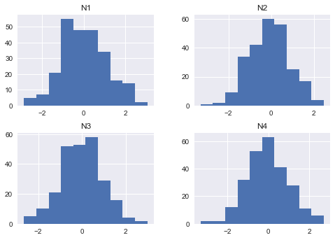

```python
frame13 = pd.DataFrame(np.random.randn(250,4),
                       columns = ['N1','N2','N3','N4'])
frame13.hist();
```

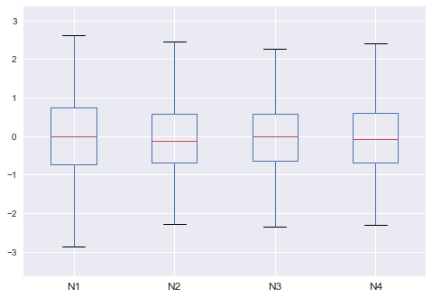

```python
frame13.boxplot();
```

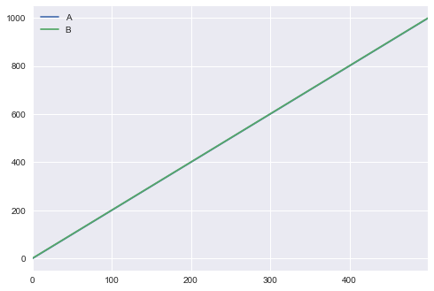

```python
frame12 = pd.DataFrame(np.arange(1000).reshape(500,2),
                       columns = ['A','B'])
frame12.plot();
```

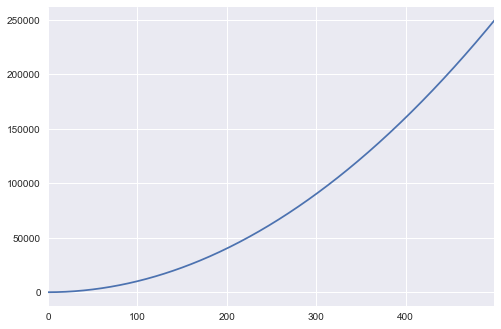

```python
frame12['A'].cumsum().plot();
```

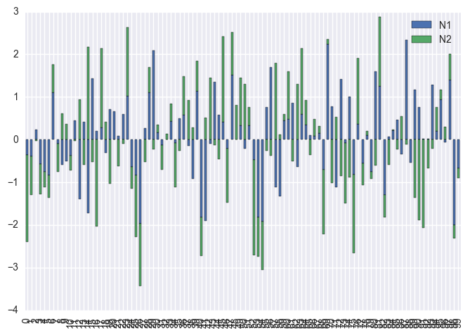

```python
frame14 = pd.DataFrame(np.random.randn(100,2),columns = ['N1','N2'])
frame14.plot(kind ='bar', stacked = True);
```

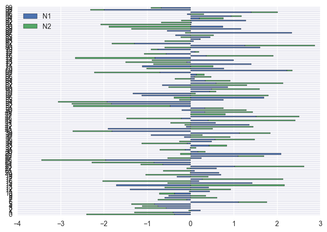

```python
frame14.plot(kind ='barh', stacked = True);
```

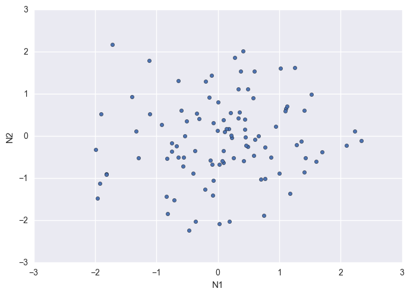

```python
frame14.plot(x = 'N1', y = 'N2', kind ='scatter');
```

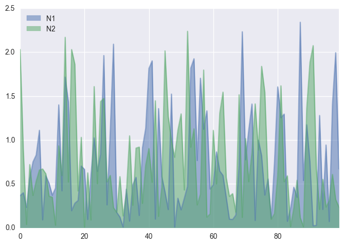

```python
np.abs(frame14).plot(kind ='area', stacked = False);
```

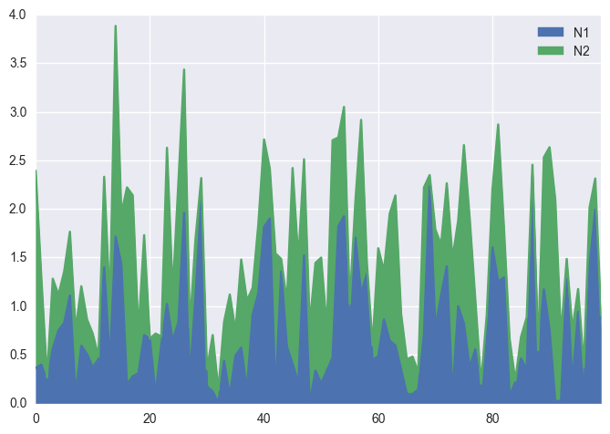

```python
np.abs(frame14).plot(kind ='area', stacked = True);
```

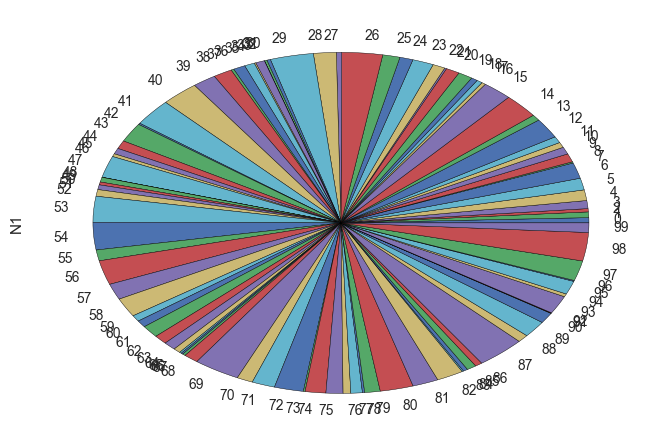

```python
np.abs(frame14['N1']).plot(kind ='pie');
```

## Financial Time series

```python
DAX = web.DataReader(name='^GDAXI', data_source='yahoo',
                     start='2000-1-1')
DAX.info()
```

```
<class 'pandas.core.frame.DataFrame'>
DatetimeIndex: 4403 entries, 2000-01-03 to 2017-04-11
Data columns (total 6 columns):
Open         4403 non-null float64
High         4403 non-null float64
Low          4403 non-null float64
Close        4403 non-null float64
Volume       4403 non-null int64
Adj Close    4403 non-null float64
dtypes: float64(5), int64(1)
memory usage: 240.8 KB
```

```python
DAX.tail()
```

| Date | Open | High | Low | Close | Volume | Adj Close |
| --- | --- | --- | --- | --- | --- | --- |
| 2017-04-05 | 12280.059570 | 12293.129883 | 12212.169922 | 12217.540039 | 84216400 | 12217.540039 |
| 2017-04-06 | 12147.370117 | 12242.500000 | 12119.040039 | 12230.889648 | 74256200 | 12230.889648 |
| 2017-04-07 | 12174.509766 | 12225.059570 | 12144.980469 | 12225.059570 | 71891000 | 12225.059570 |
| 2017-04-10 | 12244.500000 | 12246.879883 | 12178.099609 | 12200.519531 | 56772300 | 12200.519531 |
| 2017-04-11 | 12149.400391 | 12221.429688 | 12049.929688 | 12139.349609 | 81596000 | 12139.349609 |

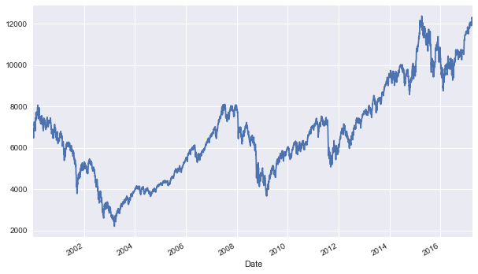

```python
DAX['Close'].plot(figsize=(10,6));
```

```python
DAX['42'] = DAX['Close'].rolling(window=252).mean()
DAX['252'] = DAX['Close'].rolling(window=252).mean()
```

```python
DAX[['Close', '42', '252']].tail()
```

| Date | Close | 42 | 252 |
| --- | --- | --- | --- |
| 2017-04-05 | 12217.540039 | 10786.305990 | 10786.305990 |
| 2017-04-06 | 12230.889648 | 10794.787098 | 10794.787098 |
| 2017-04-07 | 12225.059570 | 10803.412055 | 10803.412055 |
| 2017-04-10 | 12200.519531 | 10811.666857 | 10811.666857 |
| 2017-04-11 | 12139.349609 | 10818.769078 | 10818.769078 |

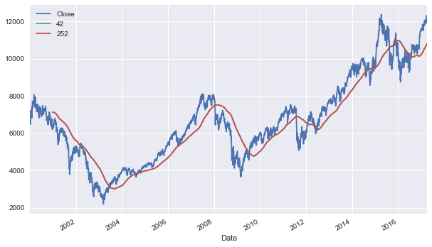

```python
DAX[['Close', '42', '252']].plot(figsize=(10, 6));
```

```python
DAX['Ret_Loop'] = 0.0
log_rets = []
for i in range(1, len(DAX)):
    log_rets.append(math.log(DAX['Close'][i] /
                        DAX['Close'][i - 1]))
DAX['Ret_Loop'].ix[1:] = log_rets
```

```python
DAX[['Close', 'Ret_Loop']].tail()
```

[output not shown]

```python
DAX['Return'] = np.log(DAX['Close'] / DAX['Close'].shift(1))
```

```python
DAX[['Close','Return']].tail()
```

| Date | Close | Return |
| --- | --- | --- |
| 2017-04-05 | 12217.540039 | -0.005290 |
| 2017-04-06 | 12230.889648 | 0.001092 |
| 2017-04-07 | 12225.059570 | -0.000477 |
| 2017-04-10 | 12200.519531 | -0.002009 |
| 2017-04-11 | 12139.349609 | -0.005026 |

```python
# del DAX['Ret_Loop']
```

```python
DAX['Mov_vol'] = Series.rolling(DAX['Return'],
                                window = 252).std() * math.sqrt(252)
# moving annualized volatility
```

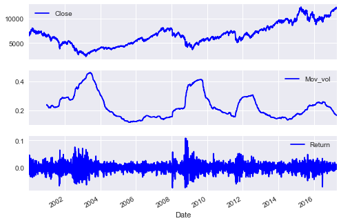

```python
DAX[['Close','Mov_vol','Return']].plot(subplots=True , style ='b');
```

```python
symbols1 = ['GLD', 'SLV']

from pandas_datareader import data as web
regre = pd.DataFrame()
for sym in symbols1:
    regre[sym] = web.DataReader(sym, data_source='yahoo')['Adj Close']
```

```python
xdat = regre['GLD']
ydat = regre['SLV']
exo = sm.add_constant(xdat)
model = sm.OLS(ydat , xdat)
results = model.fit()
print(results.summary())
#model = pd.ols(y = ydat , x = xdat)
#model
```

```
                            OLS Regression Results
==============================================================================
Dep. Variable:                    SLV   R-squared:                       0.963
Model:                            OLS   Adj. R-squared:                  0.963
Method:                 Least Squares   F-statistic:                 4.726e+04
Date:                Wed, 12 Apr 2017   Prob (F-statistic):               0.00
Time:                        10:49:08   Log-Likelihood:                -5358.5
No. Observations:                1831   AIC:                         1.072e+04
Df Residuals:                    1830   BIC:                         1.072e+04
Df Model:                           1
Covariance Type:            nonrobust
==============================================================================
                 coef    std err          t      P>|t|      [95.0% Conf. Int.]
------------------------------------------------------------------------------
GLD            0.1727      0.001    217.396      0.000         0.171     0.174
==============================================================================
Omnibus:                      525.686   Durbin-Watson:                   0.007
Prob(Omnibus):                  0.000   Jarque-Bera (JB):             1271.508
Skew:                           1.570   Prob(JB):                    7.86e-277
Kurtosis:                       5.609   Cond. No.                         1.00
==============================================================================

Warnings:
[1] Standard Errors assume that the covariance matrix of the errors is correctly specified.
```

```python
results.params[0]
```

```
0.17273336245916279
```

```python
results.tvalues
```

[output not shown]

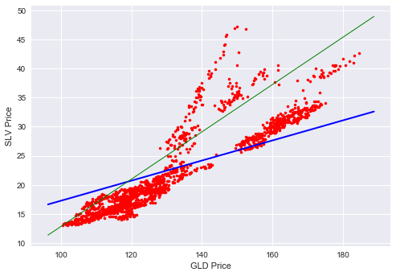

```python
plt.plot(xdat,ydat , 'r.')
ax = plt.axis() # grab axis values
x = np.linspace(ax[0], ax[1])
y = np.linspace(ax[2],ax[3])
plt.plot(x, results.params[0] * x,'b', lw=2)
plt.plot(x,y,'g',lw=1)
plt.grid(True)
plt.axis('tight')
plt.xlabel('GLD Price')
plt.ylabel('SLV Price');
```

```python
ax[0] # min value x axis
```

```
96.295500200000006
```

```python
ax[1] # max value x axis
```

```
188.79449579999999
```

```python
ax[2] # min value y axis
```

```
11.350000100000001
```

```python
ax[3] # max value y axis
```

```
48.969997899999996
```

```python
regre.corr()
```

|  | GLD | SLV |
| --- | --- | --- |
| GLD | 1.000000 | 0.904018 |
| SLV | 0.904018 | 1.000000 |

## Hierarchical Indexing

```python
datus = pd.Series(np.random.randn(10),
                  index =[['a','a','a','b','b','b','c','c','d','d'],
                         [1,2,3,1,2,3,1,2,2,3],[4,5,6,4,5,6,4,5,5,6]])
datus
```

```
a  1  4   -1.879762
   2  5   -0.721272
   3  6   -0.338957
b  1  4    0.903168
   2  5   -1.470950
   3  6   -0.758169
c  1  4    0.508569
   2  5    0.230403
d  2  5    0.063833
   3  6    0.871196
dtype: float64
```

```python
datus['b':'c']
```

```
b  1  4    0.903168
   2  5   -1.470950
   3  6   -0.758169
c  1  4    0.508569
   2  5    0.230403
dtype: float64
```

```python
datus[:, 2]
```

```
a  5   -0.721272
b  5   -1.470950
c  5    0.230403
d  5    0.063833
dtype: float64
```

```python
datus.unstack(level = -0)
```

|  |  | a | b | c | d |
| --- | --- | --- | --- | --- | --- |
| 1 | 4 | -1.879762 | 0.903168 | 0.508569 | NaN |
| 2 | 5 | -0.721272 | -1.470950 | 0.230403 | 0.063833 |
| 3 | 6 | -0.338957 | -0.758169 | NaN | 0.871196 |

```python
datus.unstack().stack()
```

```
a  1  4   -1.879762
   2  5   -0.721272
   3  6   -0.338957
b  1  4    0.903168
   2  5   -1.470950
   3  6   -0.758169
c  1  4    0.508569
   2  5    0.230403
d  2  5    0.063833
   3  6    0.871196
dtype: float64
```

```python
datus.index.names = ['key1','key2','key3']
```

```python
datus.swaplevel('key2','key3')
```

```
key1  key3  key2
a     4     1      -1.879762
      5     2      -0.721272
      6     3      -0.338957
b     4     1       0.903168
      5     2      -1.470950
      6     3      -0.758169
c     4     1       0.508569
      5     2       0.230403
d     5     2       0.063833
      6     3       0.871196
dtype: float64
```

## Grouping Operations

```python
rows = 10000
index = pd.date_range(dt.datetime.now().date(), periods=rows, freq='H')
df15 = pd.DataFrame(np.random.standard_normal((rows, 5)),
                  columns=['No1', 'No2', 'No3', 'No4', 'No5'],
                  index=index)
```

```python
df15.info()
```

```
<class 'pandas.core.frame.DataFrame'>
DatetimeIndex: 10000 entries, 2017-02-17 00:00:00 to 2018-04-09 15:00:00
Freq: H
Data columns (total 5 columns):
No1    10000 non-null float64
No2    10000 non-null float64
No3    10000 non-null float64
No4    10000 non-null float64
No5    10000 non-null float64
dtypes: float64(5)
memory usage: 468.8 KB
```

```python
df15['Gr1'] = np.random.choice(['A', 'B', 'C', 'D'], rows)
df15.tail()
```

|  | No1 | No2 | No3 | No4 | No5 | Gr1 |
| --- | --- | --- | --- | --- | --- | --- |
| 2018-04-09 11:00:00 | 0.359121 | -0.208608 | -1.406138 | -0.083536 | 0.503503 | B |
| 2018-04-09 12:00:00 | 0.153734 | -0.676256 | -1.847270 | -0.171057 | 1.661183 | A |
| 2018-04-09 13:00:00 | 0.413483 | 0.271909 | 0.230267 | -0.787535 | 0.255218 | C |
| 2018-04-09 14:00:00 | 0.723579 | -0.405458 | -0.397035 | 1.834259 | -2.456622 | C |
| 2018-04-09 15:00:00 | -0.165863 | 0.290919 | -0.082197 | -1.127989 | -0.928091 | A |

```python
grouped = df15.groupby('Gr1')
```

```python
grouped.size()
```

```
Gr1
A    2490
B    2533
C    2515
D    2462
dtype: int64
```

```python
grouped.sum()
```

| Gr1 | No1 | No2 | No3 | No4 | No5 |
| --- | --- | --- | --- | --- | --- |
| A | -65.832954 | 32.599225 | -36.073827 | -32.602549 | 14.445845 |
| B | 94.546349 | -21.629824 | -32.044099 | 2.118852 | -43.033233 |
| C | 76.844336 | -10.563725 | 20.591604 | -11.522976 | -27.712341 |
| D | 82.275804 | 14.329325 | -17.427979 | -94.292759 | 30.566569 |

```python
grouped.describe()
```

| Gr1 |  | No1 | No2 | No3 | No4 | No5 |
| --- | --- | --- | --- | --- | --- | --- |
| A | count | 2490.000000 | 2490.000000 | 2490.000000 | 2490.000000 | 2490.000000 |
|  | mean | -0.026439 | 0.013092 | -0.014487 | -0.013093 | 0.005802 |
|  | std | 0.999929 | 1.010950 | 0.993208 | 1.016492 | 0.995122 |
|  | min | -3.619040 | -3.697266 | -3.401901 | -3.223549 | -3.763433 |
|  | 25% | -0.732133 | -0.657053 | -0.677468 | -0.703258 | -0.676058 |
|  | 50% | -0.021231 | 0.001760 | -0.005776 | -0.023152 | -0.003707 |
|  | 75% | 0.652562 | 0.703883 | 0.644075 | 0.670565 | 0.711405 |
|  | max | 4.449714 | 3.247585 | 3.485574 | 3.962545 | 3.570761 |
| B | count | 2533.000000 | 2533.000000 | 2533.000000 | 2533.000000 | 2533.000000 |
|  | mean | 0.037326 | -0.008539 | -0.012651 | 0.000836 | -0.016989 |
|  | std | 1.033164 | 0.992718 | 0.983826 | 0.999845 | 0.993736 |
|  | min | -3.269895 | -3.093452 | -3.470088 | -3.321153 | -3.926161 |
|  | 25% | -0.658344 | -0.660931 | -0.654442 | -0.688923 | -0.695666 |
|  | 50% | 0.049475 | 0.013364 | -0.027562 | 0.006449 | -0.003610 |
|  | 75% | 0.714077 | 0.663583 | 0.622105 | 0.679176 | 0.657904 |
|  | max | 3.667131 | 3.100656 | 3.775996 | 3.663145 | 2.968792 |
| C | count | 2515.000000 | 2515.000000 | 2515.000000 | 2515.000000 | 2515.000000 |
|  | mean | 0.030554 | -0.004200 | 0.008188 | -0.004582 | -0.011019 |
|  | std | 1.024763 | 1.011278 | 0.985953 | 0.985413 | 0.990020 |
|  | min | -3.304024 | -3.964124 | -3.386635 | -3.198455 | -3.877815 |
|  | 25% | -0.647735 | -0.682351 | -0.679574 | -0.655882 | -0.687612 |
|  | 50% | 0.018771 | 0.002068 | 0.021336 | 0.010492 | -0.018987 |
|  | 75% | 0.729842 | 0.683010 | 0.693707 | 0.630983 | 0.661061 |
|  | max | 3.644993 | 3.546272 | 3.277677 | 3.008363 | 3.683223 |
| D | count | 2462.000000 | 2462.000000 | 2462.000000 | 2462.000000 | 2462.000000 |
|  | mean | 0.033418 | 0.005820 | -0.007079 | -0.038299 | 0.012415 |
|  | std | 1.016331 | 1.026178 | 0.994915 | 0.986900 | 0.981773 |
|  | min | -3.108245 | -3.995202 | -3.610638 | -3.358655 | -3.535602 |
|  | 25% | -0.641369 | -0.666657 | -0.689847 | -0.718958 | -0.645479 |
|  | 50% | 0.045454 | -0.009629 | 0.009913 | -0.043021 | 0.030472 |
|  | 75% | 0.701568 | 0.704168 | 0.654711 | 0.640353 | 0.677360 |
|  | max | 3.308353 | 2.993161 | 3.353545 | 3.695270 | 3.587709 |

```python
# how to select an specific group
grouped.get_group('A').head()
```

|  | No1 | No2 | No3 | No4 | No5 |
| --- | --- | --- | --- | --- | --- |
| 2017-02-17 00:00:00 | -1.747202 | 1.183819 | 1.056063 | -0.314171 | 0.000513 |
| 2017-02-17 05:00:00 | -0.087637 | -0.407864 | 0.572638 | -2.060587 | 0.276091 |
| 2017-02-17 20:00:00 | 0.121479 | 1.630144 | 0.548125 | 0.529235 | -0.440580 |
| 2017-02-18 01:00:00 | -0.447192 | 0.806025 | 0.493980 | -0.788197 | 0.133363 |
| 2017-02-18 08:00:00 | -1.207712 | 0.772971 | -0.924623 | 0.859460 | -0.824369 |

### Custom agregations

```python
grouped.aggregate({'No1' : np.mean,'No3' : np.std})
```

| Gr1 | No1 | No3 |
| --- | --- | --- |
| A | -0.026439 | 0.993208 |
| B | 0.037326 | 0.983826 |
| C | 0.030554 | 0.985953 |
| D | 0.033418 | 0.994915 |

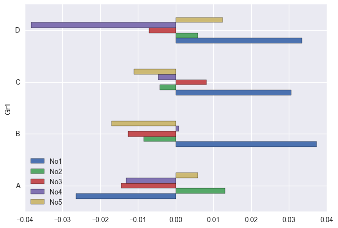

```python
grouped.mean().plot(kind='barh');
```

```python
ff = lambda x: x.hour % 2 == 0
```

```python
df15['Gr2'] = np.where(ff(df15.index), 'even','odd')
df15.tail()
```

|  | No1 | No2 | No3 | No4 | No5 | Gr1 | Gr2 |
| --- | --- | --- | --- | --- | --- | --- | --- |
| 2018-04-09 11:00:00 | 0.359121 | -0.208608 | -1.406138 | -0.083536 | 0.503503 | B | odd |
| 2018-04-09 12:00:00 | 0.153734 | -0.676256 | -1.847270 | -0.171057 | 1.661183 | A | even |
| 2018-04-09 13:00:00 | 0.413483 | 0.271909 | 0.230267 | -0.787535 | 0.255218 | C | odd |
| 2018-04-09 14:00:00 | 0.723579 | -0.405458 | -0.397035 | 1.834259 | -2.456622 | C | even |
| 2018-04-09 15:00:00 | -0.165863 | 0.290919 | -0.082197 | -1.127989 | -0.928091 | A | odd |

### Grouping using multiple columns

```python
grouped1 = df15.groupby(['Gr1','Gr2'])
grouped1.size()
```

```
Gr1  Gr2
A    even    1241
     odd     1249
B    even    1238
     odd     1295
C    even    1279
     odd     1236
D    even    1242
     odd     1220
dtype: int64
```

```python
grouped1.aggregate([np.min, np.mean, np.max])[['No1', 'No2']]
```

| Gr1 | Gr2 | No1 amin | No1 mean | No1 amax | No2 amin | No2 mean | No2 amax |
| --- | --- | --- | --- | --- | --- | --- | --- |
| A | even | -3.619040 | -0.031657 | 4.449714 | -3.697266 | 0.044113 | 3.060221 |
|  | odd | -2.865723 | -0.021254 | 3.008664 | -3.256898 | -0.017731 | 3.247585 |
| B | even | -2.981864 | 0.048692 | 3.667131 | -3.078316 | 0.013357 | 3.100656 |
|  | odd | -3.269895 | 0.026460 | 3.584745 | -3.093452 | -0.029471 | 2.698735 |
| C | even | -3.032324 | 0.075296 | 3.070334 | -3.964124 | 0.000076 | 3.473589 |
|  | odd | -3.304024 | -0.015744 | 3.644993 | -3.364398 | -0.008625 | 3.546272 |
| D | even | -3.108245 | 0.030361 | 3.308353 | -3.282875 | 0.030534 | 2.993161 |
|  | odd | -3.021058 | 0.036530 | 3.129654 | -3.995202 | -0.019340 | 2.694083 |

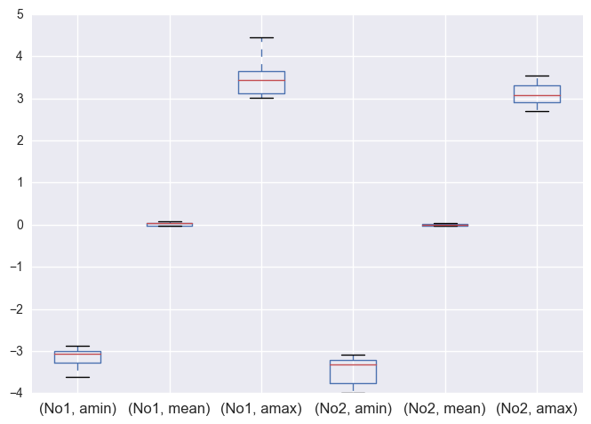

```python
grouped1.aggregate([np.min, np.mean, np.max])[['No1', 'No2']].boxplot(
                    return_type='dict');
```

```python
grouped1.filter(lambda x: np.mean(x['No2']) > 0.0).head()
```

|  | No1 | No2 | No3 | No4 | No5 | Gr1 | Gr2 |
| --- | --- | --- | --- | --- | --- | --- | --- |
| 2017-02-17 00:00:00 | -1.747202 | 1.183819 | 1.056063 | -0.314171 | 0.000513 | A | even |
| 2017-02-17 02:00:00 | -1.235347 | 0.558738 | -1.199653 | -1.066288 | -0.074571 | C | even |
| 2017-02-17 04:00:00 | -1.327208 | -0.854788 | 1.009301 | -0.475160 | 0.168962 | B | even |
| 2017-02-17 06:00:00 | -0.103332 | -0.146059 | 1.213462 | -2.007562 | -0.445208 | C | even |
| 2017-02-17 08:00:00 | -1.101979 | -0.064332 | -0.392846 | 1.116662 | 1.414924 | D | even |

## Joining, Appending, Merging

```python
#Let us start with two small sample DataFrame objects (I).
df1 = pd.DataFrame(['100', '200', '300', '400'],
                   index=['a', 'b', 'c', 'd'], columns=['A',])
df1
```

|  | A |
| --- | --- |
| a | 100 |
| b | 200 |
| c | 300 |
| d | 400 |

#### Let us start with two small sample DataFrame objects (II).

```python
df2 = pd.DataFrame(['200', '150', '50'],
                   index=['f', 'b', 'd'], columns=['B',])
df2
```

|  | B |
| --- | --- |
| f | 200 |
| b | 150 |
| d | 50 |

#### Default operations (I).

<a id ='cell73'></a>

```python
df1.append(df2)
```

|  | A | B |
| --- | --- | --- |
| a | 100 | NaN |
| b | 200 | NaN |
| c | 300 | NaN |
| d | 400 | NaN |
| f | NaN | 200 |
| b | NaN | 150 |
| d | NaN | 50 |

#### Default operations (II).

```python
df1.append(df2, ignore_index=True)
```

|  | A | B |
| --- | --- | --- |
| 0 | 100 | NaN |
| 1 | 200 | NaN |
| 2 | 300 | NaN |
| 3 | 400 | NaN |
| 4 | NaN | 200 |
| 5 | NaN | 150 |
| 6 | NaN | 50 |

#### Default operations (III).

```python
pd.concat((df1, df2))
```

|  | A | B |
| --- | --- | --- |
| a | 100 | NaN |
| b | 200 | NaN |
| c | 300 | NaN |
| d | 400 | NaN |
| f | NaN | 200 |
| b | NaN | 150 |
| d | NaN | 50 |

#### Default operations (IV).

```python
pd.concat((df1, df2), ignore_index=True)
```

|  | A | B |
| --- | --- | --- |
| 0 | 100 | NaN |
| 1 | 200 | NaN |
| 2 | 300 | NaN |
| 3 | 400 | NaN |
| 4 | NaN | 200 |
| 5 | NaN | 150 |
| 6 | NaN | 50 |

#### Default operations (V).

```python
df1.join(df2)
```

|  | A | B |
| --- | --- | --- |
| a | 100 | NaN |
| b | 200 | 150 |
| c | 300 | NaN |
| d | 400 | 50 |

#### Default operations (VI).

```python
df2.join(df1)
```

|  | B | A |
| --- | --- | --- |
| f | 200 | NaN |
| b | 150 | 200 |
| d | 50 | 400 |

#### Default operations (VII).

```python
df = pd.DataFrame()
df['A'] = df1['A']
df
```

|  | A |
| --- | --- |
| a | 100 |
| b | 200 |
| c | 300 |
| d | 400 |

```python
df['B'] = df2['B'] # sequence counts
df
```

|  | A | B |
| --- | --- | --- |
| a | 100 | NaN |
| b | 200 | 150 |
| c | 300 | NaN |
| d | 400 | 50 |

#### Default operations (VIII).

```python
df = pd.DataFrame({'A': df1['A'], 'B': df2['B']})
df
```

|  | A | B |
| --- | --- | --- |
| a | 100 | NaN |
| b | 200 | 150 |
| c | 300 | NaN |
| d | 400 | 50 |
| f | NaN | 200 |

#### Variants of joining data (I).

```python
df1.join(df2, how='left') # default
```

|  | A | B |
| --- | --- | --- |
| a | 100 | NaN |
| b | 200 | 150 |
| c | 300 | NaN |
| d | 400 | 50 |

#### Variants of joining data (II).

```python
df1.join(df2, how='right')
```

|  | A | B |
| --- | --- | --- |
| f | NaN | 200 |
| b | 200 | 150 |
| d | 400 | 50 |

#### Variants of joining data (III).

```python
df1.join(df2, how='inner')
```

|  | A | B |
| --- | --- | --- |
| b | 200 | 150 |
| d | 400 | 50 |

#### Variants of joining data (IV).

```python
df1.join(df2, how='outer')
```

|  | A | B |
| --- | --- | --- |
| a | 100 | NaN |
| b | 200 | 150 |
| c | 300 | NaN |
| d | 400 | 50 |
| f | NaN | 200 |

#### Variants of joining data (V).

```python
df1.join(df2, how='outer', sort=True)
```

|  | A | B |
| --- | --- | --- |
| a | 100 | NaN |
| b | 200 | 150 |
| c | 300 | NaN |
| d | 400 | 50 |
| f | NaN | 200 |

#### Adding a further column to both DataFrame objects..

```python
c = pd.Series([250, 150, 50], index=['b', 'd', 'c'])
df1['C'] = c
df2['C'] = c
```

#### Resulting objects.

```python
df1
```

|  | A | C |
| --- | --- | --- |
| a | 100 | NaN |
| b | 200 | 250.0 |
| c | 300 | 50.0 |
| d | 400 | 150.0 |

```python
df2
```

|  | B | C |
| --- | --- | --- |
| f | 200 | NaN |
| b | 150 | 250.0 |
| d | 50 | 150.0 |

#### Default merging of the objects.

```python
pd.merge(df1, df2)
```

|  | A | C | B |
| --- | --- | --- | --- |
| 0 | 100 | NaN | 200 |
| 1 | 200 | 250.0 | 150 |
| 2 | 400 | 150.0 | 50 |

#### Other merging variants (I).

```python
pd.merge(df1, df2, how='outer')
```

|  | A | C | B |
| --- | --- | --- | --- |
| 0 | 100 | NaN | 200 |
| 1 | 200 | 250.0 | 150 |
| 2 | 300 | 50.0 | NaN |
| 3 | 400 | 150.0 | 50 |

#### Other merging variants (I).

```python
pd.merge(df1, df2, on='C') # default
```

|  | A | C | B |
| --- | --- | --- | --- |
| 0 | 100 | NaN | 200 |
| 1 | 200 | 250.0 | 150 |
| 2 | 400 | 150.0 | 50 |

#### Other merging variants (II).

```python
pd.merge(df1, df2, left_on='A', right_on='B', how='outer')
```

|  | A | C_x | B | C_y |
| --- | --- | --- | --- | --- |
| 0 | 100 | NaN | NaN | NaN |
| 1 | 200 | 250.0 | 200 | NaN |
| 2 | 300 | 50.0 | NaN | NaN |
| 3 | 400 | 150.0 | NaN | NaN |
| 4 | NaN | NaN | 150 | 250.0 |
| 5 | NaN | NaN | 50 | 150.0 |

#### Other merging variants (III).

```python
pd.merge(df1, df2, left_index=True, right_index=True)
```

|  | A | C_x | B | C_y |
| --- | --- | --- | --- | --- |
| b | 200 | 250.0 | 150 | 250.0 |
| d | 400 | 150.0 | 50 | 150.0 |

```python
pd.merge(df1, df2, on='C', left_index=True, right_index=True)
```

|  | A | C | B |
| --- | --- | --- | --- |
| b | 200 | 250.0 | 150 |
| d | 400 | 150.0 | 50 |

```python
data = np.random.standard_normal((10000000, 2))
df20 = pd.DataFrame(data, columns=['x', 'y'])
```

```python
res = df20[(df20['x'] > 4.5) | (df20['y'] < -4.5)]
res[:5]
```

|  | x | y |
| --- | --- | --- |
| 40548 | 4.748838 | -0.659794 |
| 47465 | 4.504125 | 1.168248 |
| 128344 | -1.397594 | -4.726598 |
| 334886 | -1.131372 | -4.836491 |
| 352564 | 2.472851 | -4.694806 |

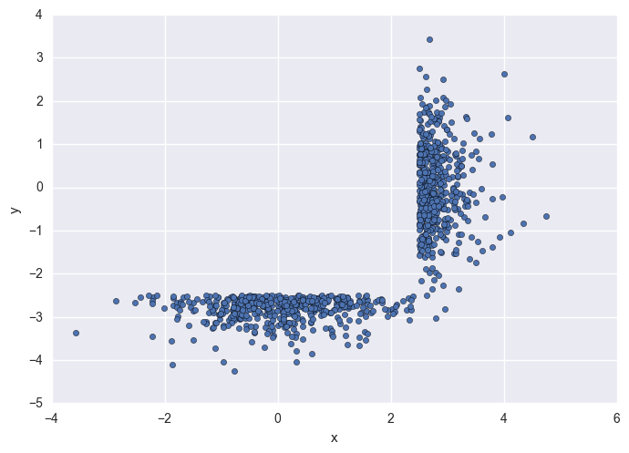

```python
df20[(df20['x'] > 2.5) | (df20['y'] < -2.5)][:1000].plot(
                        x='x', y='y', kind='scatter');
```

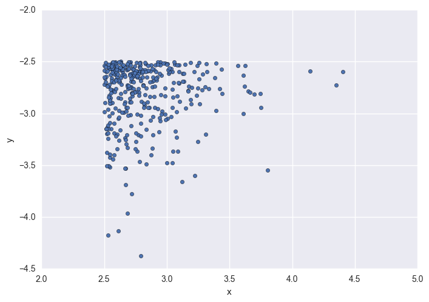

```python
df20[(df20.x > 2.5) & (df20.y < -2.5)][:1000].plot(x='x', y='y', kind='scatter');
```

## Very good way to select a pandas column

df['x'] = df.x

## More on Visualization

```python
np.random.seed(1000)
data = np.random.standard_normal((500, 2)).cumsum(axis=0)
index = pd.date_range(start='2015-1-1', periods=len(data), freq='B')
```

```python
df21 = pd.DataFrame(data, index=index, columns=['A', 'B'])
```

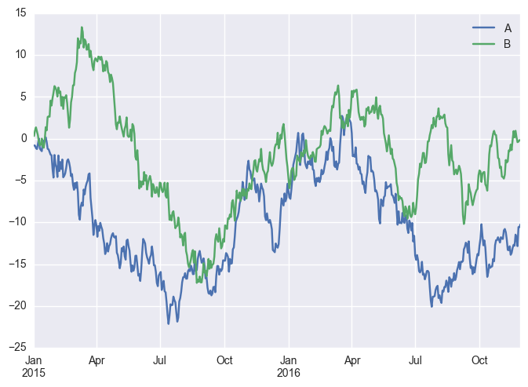

```python
df21.plot();
```

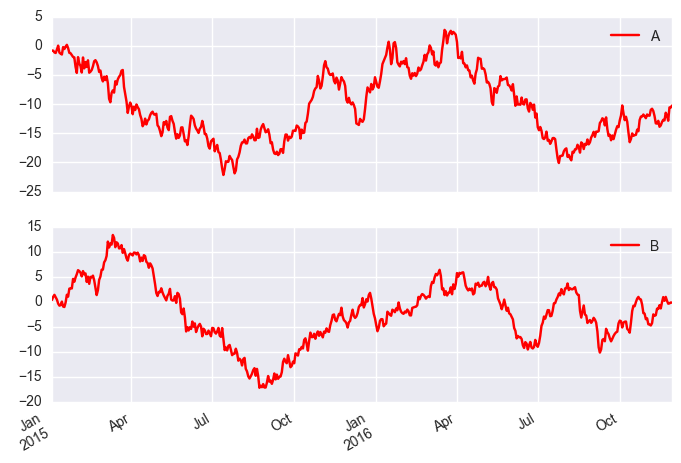

```python
df21.plot(subplots=True, color='r');
```

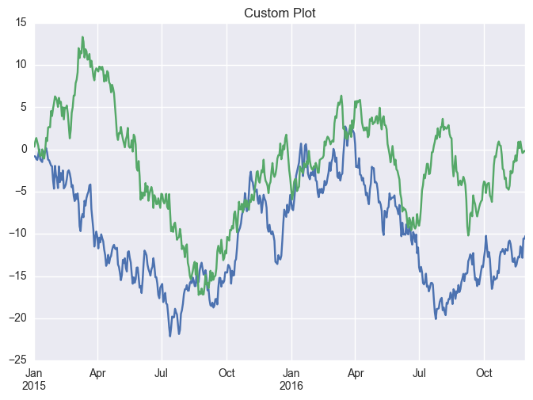

```python
df21.plot(legend=False, title='Custom Plot');
```

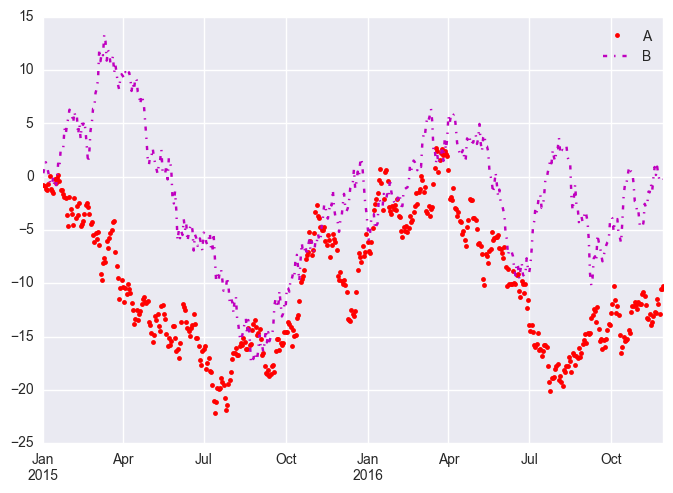

```python
df21.plot(style=['r.', 'm-.']);
```

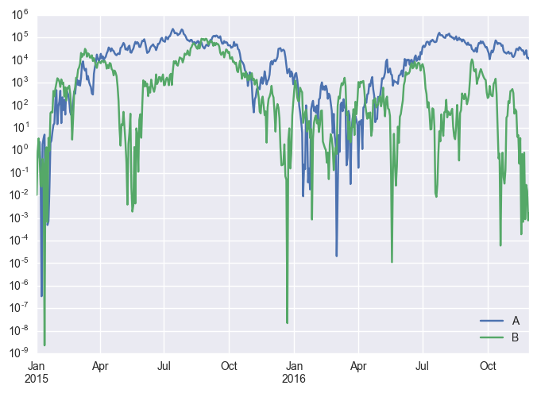

```python
(df21 ** 4).plot(logy=True);
```

```python
df21['B'] = df21['B'] * 100
```

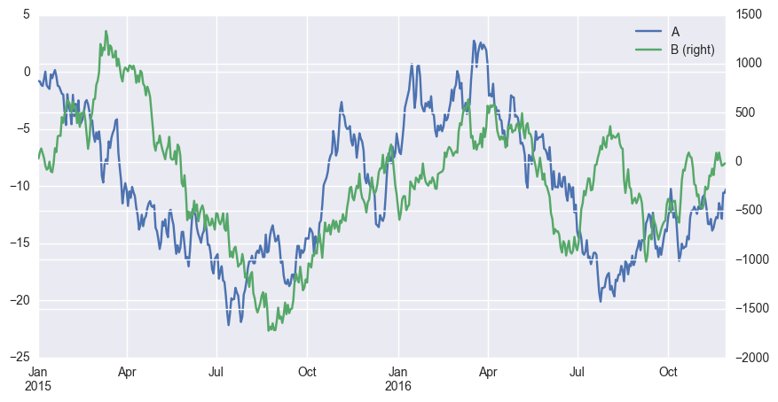

```python
df21.plot(secondary_y='B', grid=True, figsize=(10, 5));
```

### from np.datetime64 to timestamp

```python
d = '2017-03-28T00:00:00.000000000'
```

```python
np.datetime64(d)
```

```
numpy.datetime64('2017-03-28T00:00:00.000000000')
```

```python
tstamp = pd.Timestamp(d)
```

```python
tstamp
```

```
Timestamp('2017-03-28 00:00:00')
```

## Importing Excel file with multiple sheets

```python
# Step 1 --> Import excel file into Python
RawData= pd.ExcelFile\
("C:/Users/maria/OneDrive - Scandizzo & Partner, LLC/Education/Python/Mariano's Book/Latest/Loans.xlsx")
```

```python
# Step 2 --> You get the list of sheets in the excel file
# Create a Dictionary where every key has on sheet
sheetnames = RawData.sheet_names
excel = {}

for sheet in sheetnames:
    excel[sheet] = RawData.parse(sheet)
```

```python
# Step 3 --> Every sheet is already a Pandas dataframe !!
type(excel['SBK'])
```

```
pandas.core.frame.DataFrame
```

```python
# Step 4 --> You just simplify the syntax (Optional)
SBK = excel['SBK']
CF = excel['CF']
```

## Sending data to Excel File

```python
writer = pd.ExcelWriter('path',engine='xlsxwriter')
Dataframe.to_excel(writer, sheet_name= '3 Years Totals')
writer.save()
```

## Pivot tables in Pandas

```python
SBKCF = CF.query('Type != ["Loan Inflow"]')
```

```python
SBKFiltered = pd.pivot_table(SBKCF, index = ['Cash Flow','Type'],
              values = ['2,017','2,018','2,019','2,020'],\
              aggfunc = np.sum,
              margins = True)
```

```python
SBKFiltered = SBKFiltered.applymap(lambda x: '{:,.0f}'.format(x))
```

```python
SBKFiltered
```

| Cash Flow | Type | 2,017 | 2,018 | 2,019 | 2,020 |
| --- | --- | --- | --- | --- | --- |
| Inflows | Growth | 26,782,300 | 37,010,934 | 46,180,305 | 51,420,281 |
|  | Income | 209,529,393 | 238,914,746 | 241,060,921 | 238,535,921 |
|  | Sale Inflow | 195,093,846 | 100,000,000 | 155,430,000 | 207,240,000 |
| Outflows | Expenses | -299,348,818 | -334,866,086 | -264,493,500 | -266,889,325 |
|  | Investment | -69,532,401 | -56,847,542 | -56,757,632 | -49,133,583 |
|  | Loan outflows | -231,928,572 | -267,920,238 | -227,898,395 | -226,323,181 |
| All |  | -169,404,252 | -283,708,186 | -106,478,302 | -45,149,888 |

### Convert Dataframe to HTML

```python
SBKFiltered.to_html(classes='table table-striped')
```

[output not shown]

## How to apply a formula to every row of a dataframe

```python
def f(row):
    if row['Period'] == 'monthly' and row['Category'] == 'HRCost' and row['Label'] != 'Emirati':
        val = row['Values'] * (1 + parameter.ix['Visa_Cost'][0] + parameter.ix['Health_Care'][0]\
                                    * (1 + parameter.ix['Buffer'][0])) * parameter.ix['Month'][0]

    elif row['Period'] == 'monthly' and row['Category'] == 'HRCost' and row['Label'] == 'Emirati':
        val = row['Values'] * (1 + parameter.ix['Health_Care'][0]\
                                    * (1 + parameter.ix['Buffer'][0])) * parameter.ix['Month'][0]

    elif row['Period'] == 'monthly' and row['Category'] == 'FixedCost':
        val = row['Values'] * (1 + parameter.ix['Buffer_Exp'][0]) * parameter.ix['Month'][0]

    else:
        val = 0

    return val
month['Annual'] = month.apply(f, axis = 1) # This is the new column where the value will be
                                        # calculated
```

[output not shown]

### IPython display

```python
from IPython.display import display
```

```python
# example
def triple(x):
    return x * 3
```

```python
display(triple(10))
display(triple('hello'))
```

```
30
```

```
'hellohellohello'
```

```python
from IPython.display import IFrame # Image if you want to put the path to a picture
```

```python
IFrame('http://wikipedia.org', width ='100%', height=250)
```

[interactive chart not shown]